# Part I - (Used Car Data Exploration)

## Introduction

About:

There is an automobile company XYZ from India which aspires to enter the Indian used-car market by setting up their company locally to give competition to their counterparts.

They want to understand the factors affecting the pricing of cars in the market, since those may be very different from the new car market. Essentially, the company wants to know: Which variables are significant in predicting the price of a used car? How well those variables describe the price of a car Based on various market surveys, the consulting firm has gathered a large dataset of different types of used cars across the market. The Dataset contains the various variables that will be useful in the analysis process, Sales_ID,name,year,selling_price,km_driven,Region,stateor Province,city,fuel,seller type,owner,mileage,engine,maxpower,seats,sold. The datset is taken from kaggle.com

## Preliminary Wrangling

```python
# import all packages and set plots to be embedded inline
import numpy as np
import pandas as pd
import matplotlib.pyplot as plt
import seaborn as sns

%matplotlib inline
import warnings
warnings.filterwarnings('ignore')# would not show unnecessary warning messages
```

# Gathering Data

```python
#Data downloaded from Kaggle.com
used_car =pd.read_csv('UserCarData.csv')
```

# Assessing Data

```python
# loading the used car data for visual assessment
#pd.set_option('display.max_columns',None)
#pd.set_option('display.max_rows',None)
used_car.head()
```

|  | Sales_ID | name | year | selling_price | km_driven | Region | State or Province | City | fuel | seller_type | transmission | owner | mileage | engine | max_power | torque | seats | sold |
| --- | --- | --- | --- | --- | --- | --- | --- | --- | --- | --- | --- | --- | --- | --- | --- | --- | --- | --- |
| 0 | 1 | Maruti | 2014 | 450000 | 145500 | East | District of Columbia | Washington | Diesel | Individual | Manual | First_Owner | 23.40 | 1248 | 74.00 | 190Nm@ 2000rpm | 5 | Y |
| 1 | 2 | Skoda | 2014 | 370000 | 120000 | East | New York | New York City | Diesel | Individual | Manual | Second_Owner | 21.14 | 1498 | 103.52 | 250Nm@ 1500-2500rpm | 5 | Y |
| 2 | 3 | Honda | 2006 | 158000 | 140000 | Central | Illinois | Chicago | Petrol | Individual | Manual | Third_Owner | 17.70 | 1497 | 78.00 | 12.7@ 2,700(kgm@ rpm) | 5 | Y |
| 3 | 4 | Hyundai | 2010 | 225000 | 127000 | Central | Illinois | Chicago | Diesel | Individual | Manual | First_Owner | 23.00 | 1396 | 90.00 | 22.4 kgm at 1750-2750rpm | 5 | Y |
| 4 | 5 | Maruti | 2007 | 130000 | 120000 | East | New York | New York City | Petrol | Individual | Manual | First_Owner | 16.10 | 1298 | 88.20 | 11.5@ 4,500(kgm@ rpm) | 5 | Y |

```python
used_car.info()
```

```
<class 'pandas.core.frame.DataFrame'>
RangeIndex: 7906 entries, 0 to 7905
Data columns (total 18 columns):
 #   Column             Non-Null Count  Dtype
---  ------             --------------  -----
 0   Sales_ID           7906 non-null   int64
 1   name               7906 non-null   object
 2   year               7906 non-null   int64
 3   selling_price      7906 non-null   int64
 4   km_driven          7906 non-null   int64
 5   Region             7906 non-null   object
 6   State or Province  7906 non-null   object
 7   City               7906 non-null   object
 8   fuel               7906 non-null   object
 9   seller_type        7906 non-null   object
 10  transmission       7906 non-null   object
 11  owner              7906 non-null   object
 12  mileage            7906 non-null   float64
 13  engine             7906 non-null   int64
 14  max_power          7906 non-null   float64
 15  torque             7906 non-null   object
 16  seats              7906 non-null   int64
 17  sold               7906 non-null   object
dtypes: float64(2), int64(6), object(10)
memory usage: 1.1+ MB
```

```python
# to check for  total duplicates
used_car.duplicated().sum()
```

```
0
```

```python
# to check for total missing values
used_car.isnull().sum()
```

```
Sales_ID             0
name                 0
year                 0
selling_price        0
km_driven            0
Region               0
State or Province    0
City                 0
fuel                 0
seller_type          0
transmission         0
owner                0
mileage              0
engine               0
max_power            0
torque               0
seats                0
sold                 0
dtype: int64
```

```python
# getting the statistics analysis
used_car.describe()
```

|  | Sales_ID | year | selling_price | km_driven | mileage | engine | max_power | seats |
| --- | --- | --- | --- | --- | --- | --- | --- | --- |
| count | 7906.000000 | 7906.000000 | 7.906000e+03 | 7.906000e+03 | 7906.000000 | 7906.000000 | 7906.000000 | 7906.000000 |
| mean | 4070.106248 | 2013.983936 | 6.498137e+05 | 6.918866e+04 | 19.419861 | 1458.708829 | 91.587374 | 5.416393 |
| std | 2345.770159 | 3.863695 | 8.135827e+05 | 5.679230e+04 | 4.036263 | 503.893057 | 35.747216 | 0.959208 |
| min | 1.000000 | 1994.000000 | 2.999900e+04 | 1.000000e+00 | 0.000000 | 624.000000 | 32.800000 | 2.000000 |
| 25% | 2037.250000 | 2012.000000 | 2.700000e+05 | 3.500000e+04 | 16.780000 | 1197.000000 | 68.050000 | 5.000000 |
| 50% | 4076.500000 | 2015.000000 | 4.500000e+05 | 6.000000e+04 | 19.300000 | 1248.000000 | 82.000000 | 5.000000 |
| 75% | 6102.000000 | 2017.000000 | 6.900000e+05 | 9.542500e+04 | 22.320000 | 1582.000000 | 102.000000 | 5.000000 |
| max | 8128.000000 | 2020.000000 | 1.000000e+07 | 2.360457e+06 | 42.000000 | 3604.000000 | 400.000000 | 14.000000 |

```python
# the correlation analysis of the numerical variables
used_car.corr()
```

|  | Sales_ID | year | selling_price | km_driven | mileage | engine | max_power | seats |
| --- | --- | --- | --- | --- | --- | --- | --- | --- |
| Sales_ID | 1.000000 | -0.001304 | -0.012125 | 0.009556 | 0.028627 | -0.011279 | -0.003717 | -0.014154 |
| year | -0.001304 | 1.000000 | 0.412302 | -0.428548 | 0.328544 | 0.018263 | 0.226598 | -0.007923 |
| selling_price | -0.012125 | 0.412302 | 1.000000 | -0.222158 | -0.126280 | 0.455682 | 0.749674 | 0.041617 |
| km_driven | 0.009556 | -0.428548 | -0.222158 | 1.000000 | -0.172980 | 0.206031 | -0.038159 | 0.227259 |
| mileage | 0.028627 | 0.328544 | -0.126280 | -0.172980 | 1.000000 | -0.576408 | -0.374621 | -0.451700 |
| engine | -0.011279 | 0.018263 | 0.455682 | 0.206031 | -0.576408 | 1.000000 | 0.703975 | 0.611103 |
| max_power | -0.003717 | 0.226598 | 0.749674 | -0.038159 | -0.374621 | 0.703975 | 1.000000 | 0.191999 |
| seats | -0.014154 | -0.007923 | 0.041617 | 0.227259 | -0.451700 | 0.611103 | 0.191999 | 1.000000 |

```python
# getting the first five rows
used_car.head()
```

|  | Sales_ID | name | year | selling_price | km_driven | Region | State or Province | City | fuel | seller_type | transmission | owner | mileage | engine | max_power | torque | seats | sold |
| --- | --- | --- | --- | --- | --- | --- | --- | --- | --- | --- | --- | --- | --- | --- | --- | --- | --- | --- |
| 0 | 1 | Maruti | 2014 | 450000 | 145500 | East | District of Columbia | Washington | Diesel | Individual | Manual | First_Owner | 23.40 | 1248 | 74.00 | 190Nm@ 2000rpm | 5 | Y |
| 1 | 2 | Skoda | 2014 | 370000 | 120000 | East | New York | New York City | Diesel | Individual | Manual | Second_Owner | 21.14 | 1498 | 103.52 | 250Nm@ 1500-2500rpm | 5 | Y |
| 2 | 3 | Honda | 2006 | 158000 | 140000 | Central | Illinois | Chicago | Petrol | Individual | Manual | Third_Owner | 17.70 | 1497 | 78.00 | 12.7@ 2,700(kgm@ rpm) | 5 | Y |
| 3 | 4 | Hyundai | 2010 | 225000 | 127000 | Central | Illinois | Chicago | Diesel | Individual | Manual | First_Owner | 23.00 | 1396 | 90.00 | 22.4 kgm at 1750-2750rpm | 5 | Y |
| 4 | 5 | Maruti | 2007 | 130000 | 120000 | East | New York | New York City | Petrol | Individual | Manual | First_Owner | 16.10 | 1298 | 88.20 | 11.5@ 4,500(kgm@ rpm) | 5 | Y |

### What is the structure of your dataset?

The struxture of my data set is 7906 observations and 18 features

There are no missing values and no duplicates so no cleaning was needed

### What is/are the main feature(s) of interest in your dataset?

The fuel

The Region

The mileage

The name of the car

transmission

km _driven

owner

### What features in the dataset do you think will help support your investigation into your feature(s) of interest?

Sold and the selling price

## Univariate Exploration

```python
#the different races and the number killed
sold_counts = used_car.sold.value_counts()
```

```python
# the different race classes
sold_counts.index.values
```

```
array(['N', 'Y'], dtype=object)
```

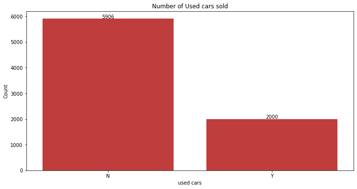

```python
#plotting a bar plot and using text annotation the values on the bars
plt.figure(figsize=(12,6))

base_color = sns.color_palette()[3]
sns.barplot(sold_counts.index.values,sold_counts,color = base_color)
plt.title('Number of Used cars sold')
plt.xlabel('used cars')
plt.ylabel('Count')
base_color = sns.color_palette()[0]
# get the current tick locations and labels
# logic to print the values on each bar
for i in range(sold_counts.shape[0]):
    count = sold_counts[i]
#print the values on top of the bars
    plt.text(i,count+170,count,ha ='center',va = 'top');
```

Obsevation

it indicates that only 2000 cars have been sold and more than half of the cars remain unsold.

### What is the frequency distribution of the car names

```python
#the first twenty brand names
name_types = used_car.name.value_counts()[:20]
```

```python
name_types.index
```

```
Index(['Maruti', 'Hyundai', 'Mahindra', 'Tata', 'Honda', 'Toyota', 'Ford',
       'Chevrolet', 'Renault', 'Volkswagen', 'BMW', 'Skoda', 'Nissan',
       'Jaguar', 'Volvo', 'Datsun', 'Mercedes', 'Fiat', 'Audi', 'Lexus'],
      dtype='object')
```

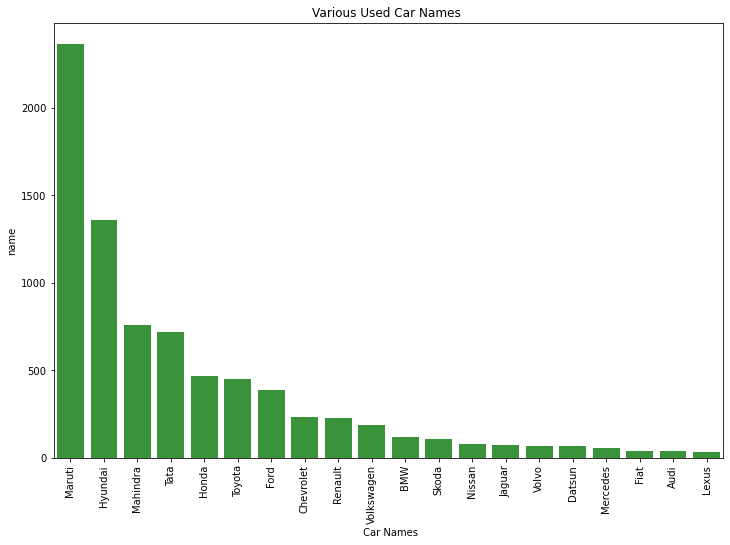

```python
#plotting the frequency distribution og the names
plt.figure(figsize=(12, 8))
base_color =sns.color_palette()[2]
plt.title('Various Used Car Names ')
plt.xlabel(' Car Names')
plt.ylabel('Count')
sns.barplot(name_types.index,name_types,color = base_color);
plt.xticks(rotation=90);
```

Obsevation

it can be seen that the brand of cars that is most frequent are Maurti, Myundai,Mahindra and Tata . we will have to find out whether the are the highest selling cars

## The types of transmission that the used cars have and their percentage

```python
trans_type =used_car.transmission.value_counts()
trans_type
```

```
Manual       6865
Automatic    1041
Name: transmission, dtype: int64
```

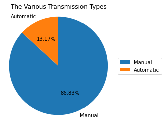

```python
#The axis function call and 'square' argument makes it so that the scaling of the plot is equal on both the x- and y-axes.
#Without this call, the pie could end up looking oval-shaped, rather than a circle.
label = used_car.transmission.value_counts().index
plt.pie(trans_type,labels =label,startangle =90,autopct='%1.2f%%',counterclock =False)
title =plt.title('The Various Transmission Types')
title.set_ha('center')
plt.legend( bbox_to_anchor=(1,0.5), loc="center right", fontsize=10,
           bbox_transform=plt.gcf().transFigure)
plt.axis('square');
```

Observation

it indicates that Manual trnsmission cars account for a higher percentage which is 86.3% while Automatic transnission accounts for a lesser occurence which is 13.17%

## What is the The Frequency Count of Fuel in the Dataset

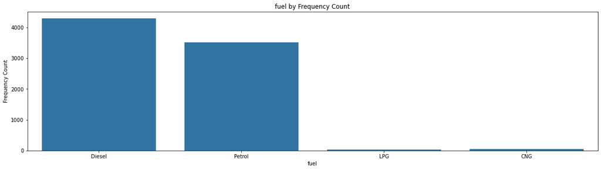

```python
x ='Fuel Types'
y='Frequency Count'


def countplot(x):
  # data setup
    plt.figure(figsize =(20,5))
    base_color = sns.color_palette()[0]
    sns.countplot(data = used_car, x=x, color = base_color)

    plt.title('{} by {}' .format(x,y))
    plt.xlabel('{}'.format(x))
    plt.ylabel('{}'.format(y));

countplot('fuel')
```

Obsevation

THe Diesel has the highest frequency distribution

## # What is the The Frequency Count of Region in the Dataset

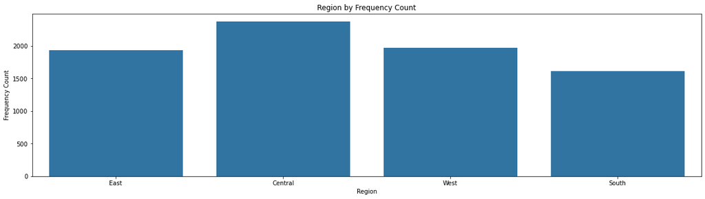

```python
countplot('Region')
x ='Region'
```

Observation

Most of the used cars are from the central region

## # What is the The Frequency Count of Owner in the Dataset

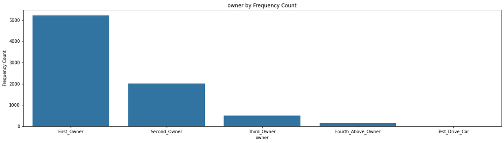

```python
countplot('owner')
```

Obsevations

The used car are mostly owned on a first owner basis

### The Frequency distribution of the Year

```python
year_unique =used_car.year.unique()
```

```python
#sorting the year colum
year_unique.sort()
year_unique
```

```
array([1994, 1995, 1996, 1997, 1998, 1999, 2000, 2001, 2002, 2003, 2004,
       2005, 2006, 2007, 2008, 2009, 2010, 2011, 2012, 2013, 2014, 2015,
       2016, 2017, 2018, 2019, 2020], dtype=int64)
```

```python
#the value counts
year_count=used_car.year.value_counts()
year_count
```

```
2017    1010
2016     856
2018     806
2015     775
2013     668
2012     621
2014     620
2019     583
2011     570
2010     375
2009     231
2008     201
2007     173
2006     102
2005      76
2020      74
2004      51
2003      37
2002      19
2000      15
1999      14
1997       9
1998       9
2001       6
1996       2
1994       2
1995       1
Name: year, dtype: int64
```

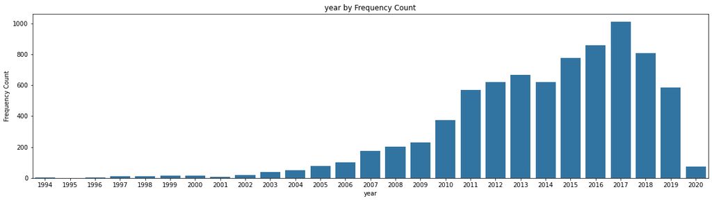

```python
countplot('year')
```

Observation

It can be observed that most of the cars were purchased recently i.e. between 2012 to 2017 this could be one of the reason why there are more numbers of cars which are unsold.

### What is the The Frequency distribution of selling price in the Dataset

```python
# the stastistical analysis of selling price
used_car.selling_price.describe()
```

```
count    7.906000e+03
mean     6.498137e+05
std      8.135827e+05
min      2.999900e+04
25%      2.700000e+05
50%      4.500000e+05
75%      6.900000e+05
max      1.000000e+07
Name: selling_price, dtype: float64
```

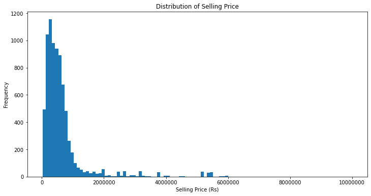

```python
#   we want the figures to retain the simple numbering of the axis
#to aviod scentific notation in general
plt.figure(figsize=(12,6))
ax = plt.gca()
ax.ticklabel_format(useOffset=False, style='plain')
ax =sns.distplot(used_car['selling_price'], kde = False, hist_kws = {'alpha' : 1},bins =100);
ax.set_title("Distribution of Selling Price")
ax.set_xlabel("Selling Price (Rs)");
ax.set_ylabel('Frequency');
```

```python
used_car['selling_price'].mode()
```

```
0    300000
dtype: int64
```

### What is the The Frequency distribution of Engine size in the Dataset

```python
used_car.engine.describe()
```

```
count    7906.000000
mean     1458.708829
std       503.893057
min       624.000000
25%      1197.000000
50%      1248.000000
75%      1582.000000
max      3604.000000
Name: engine, dtype: float64
```

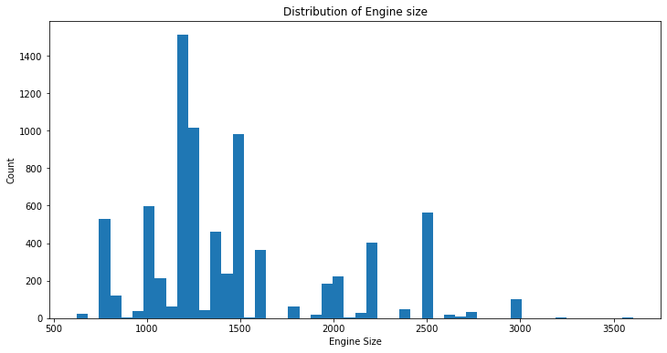

```python
#plotting the frequency distribution of engine size
plt.figure(figsize=(12,6))
ax = plt.gca()
ax.ticklabel_format(useOffset=False, style='plain')
sns.distplot(used_car['engine'], kde = False, hist_kws = {'alpha' : 1},bins =50);
plt.title("Distribution of Engine size")
plt.xlabel("Engine Size");
plt.ylabel('Count');
```

Observation most of the used car engine size range is between 1200 to 1500

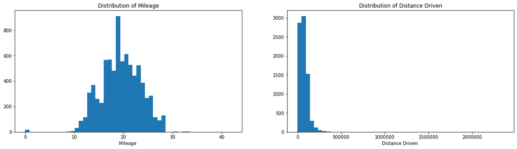

```python
#plotting the distribution of mileage and km_driven

plt.figure(figsize = [20, 5])
plt.subplot(1,2,1)
ax=sns.distplot(used_car['mileage'], kde = False, hist_kws = {'alpha' : 1},bins = 50);
ax.set_title("Distribution of Mileage")
ax.set_xlabel("Mileage ")

##########################################
#  we want the figures to retain the simple numbering of the axis
## to aviod scentific notation in general
plt.subplot(1, 2, 2) # subplot 2
ax = plt.gca()
ax.ticklabel_format(useOffset=False, style='plain')
ax =sns.distplot(used_car['km_driven'], kde = False, hist_kws = {'alpha' : 1},bins = 50);
ax.set_title("Distribution of Distance Driven")
ax.set_xlabel("Distance Driven ");
```

Observation for the Mileage most of the used cars hsve a mileage of between 10 -28

Also for the km driven it can be infered that most of the cars have not been driven much,the distribution is rightly skewed

## Insights Gained During Univariate Exploration

1.We have a large proprtion of the cars unsold whose value is 5906 while the sold used cars is only 2000

2.The used car names that has a higher frequency in the dataset is Maurti, Myundai,Mahindra and

Tata

3.For the Fuel, the Diesel accounts for a higer proportion of what the used cars use

4.Most of the used cars come from the central region

5.The used cars are owned more by individual owners

9.The used cars have not been driven much

10.Most of the cars are more of Manual than Automatic

The data set had no missing values ,duplicates so no cleaning was effected on it.

Due to the nature of the dataset We didnt need to carry out any other operations to clean and tidy data

## The Trend of Fuel Type by Year

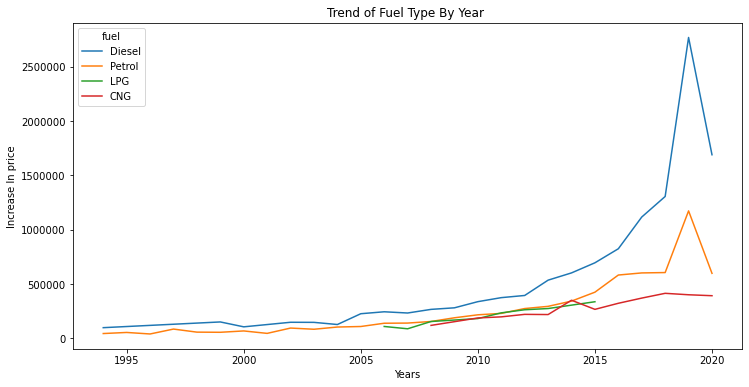

```python
#plotting the relationship between year and the selling price
plt.figure(figsize=(12,6))
ax = plt.gca()
ax.ticklabel_format(useOffset=False, style='plain', axis='y')
ax.set_xlabel('Years')
ax.set_ylabel('Increase In price')
ax.set_title("Trend of Fuel Type By Year ")
sns.lineplot(data = used_car,x ='year',y ='selling_price',hue = 'fuel',ci = None);
```

Observation

## The relationship between mileage and the selling price

to know if the mileage is higher does it command a higher sellling price

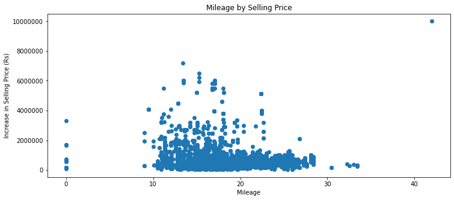

```python
#plotting the relationship between the mileage which is the fuel  consumption per kilometer
# to avoid scientific notation in general for the selling price values
plt.figure(figsize = [12, 5])
ax = plt.gca()
ax.ticklabel_format(useOffset=False, style='plain')
ax.scatter(used_car['mileage'],used_car['selling_price'],)
ax.set_title('Mileage by Selling Price')
ax.set_xlabel('Mileage')
ax.set_ylabel('Increase in Selling Price (Rs)');
```

Observation

The used cars have more mileage between 10 -30 and is where the data points are more concentrated. There is apresence of an outlier where the mileage is 40 and that commands the highest selling price The mileage doesnt really affect the price of the used car as the selling price cos as the mileage is increasing the price doesnt increase.

## The relationship between the Engine size and the selling price

To know if the engine size will predict the price of the used car

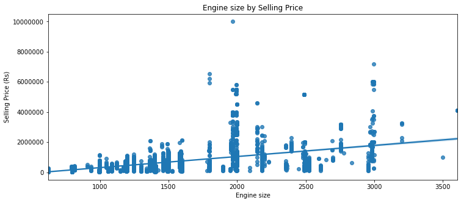

```python
#plotting the relationship between the engine size and the selling price
plt.figure(figsize = [12, 5])
ax = plt.gca()
ax.ticklabel_format(useOffset=False, style='plain')
sns.regplot(x= 'engine',y ='selling_price',data = used_car)
ax.set_title('Engine size by Selling Price')
ax.set_xlabel('Engine size')
ax.set_ylabel('Selling Price (Rs)');
```

```python
used_car[["engine", "selling_price"]].corr()
```

|  | engine | selling_price |
| --- | --- | --- |
| engine | 1.000000 | 0.455682 |
| selling_price | 0.455682 | 1.000000 |

Observation There is a weak positive relationship between selling price and Engine The data are scatteredand as it increases the selling price doesnt increase,except in some variations where the selling price above 5000000 for engine size of 2000 and 3000.

Does it affects the selling price?

[figure not shown]

```python
# plot to show the relationship betwwen distsace driven and selling price
plt.figure(figsize = (12,6))
ax = plt.gca()
ax.ticklabel_format(useOffset=False, style='plain')
sns.scatterplot(used_car.engine, used_car.km_driven)
ax.set_title('Distance Driven by Selling Price')
ax.set_xlabel('Distance Driven (km)')
ax.set_ylabel('Selling Price');
```

Observation

```python
used_car[["km_driven", "selling_price"]].corr()
```

|  | km_driven | selling_price |
| --- | --- | --- |
| km_driven | 1.000000 | -0.222158 |
| selling_price | -0.222158 | 1.000000 |

## The Relationship between the mileage and the used car Sold Status

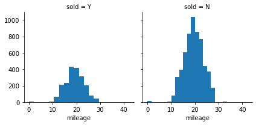

```python
#plotting a histogram using  FacetGrid to compare sold and unsold distribution of mileage
g = sns.FacetGrid(used_car, col='sold');
g.map(plt.hist, 'mileage', bins=20);
```

Observation

## The relationship between km diven and sold Status

```
(<seaborn.axisgrid.FacetGrid at 0x2d63b46d30>,)
```

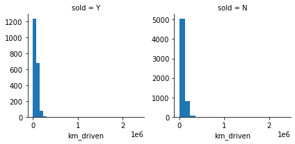

```python
#plotting a histogram using  FacetGrid to compare sold and unsold distribution of km_ driven
plt.figure(figsize = (12,6))
ax.ticklabel_format(useOffset=False, style='plain')
g = sns.FacetGrid(used_car, col='sold', sharey=False)
g.map(plt.hist, 'km_driven', bins=20),
```

Observation

The used cars are not driven so most of the used cars remain unsold the proportion of the used cars sold is just 1200 comparable to 5000 that has been unsold

## The relationship between engine size and the Sold Status

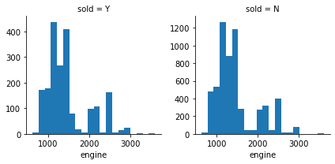

```python
#plotting a plot to show the relationship between engine  size and sold
ax.ticklabel_format(useOffset=False, style='plain')
g = sns.FacetGrid(used_car, col='sold', sharey=False);
g.map(plt.hist, 'engine', bins=20);
```

Obsevation

As the engine size increases from 1000 to 3000, a high proportion of used cars still remain unsold .The proportion of used cars being sold is just above 400 comparable to 1200 being unsold

## The relationship between year and the mileage

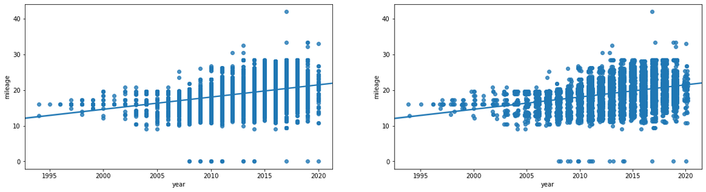

```python
# plotting a plot to show the relationship between year and mileage
plt.figure(figsize = [20, 5])
# PLOT ON LEFT - SIMPLE SCATTER
plt.subplot(1, 2, 1)
sns.regplot(data = used_car, x = 'year', y = 'mileage', truncate=False);

##########################################
# PLOT ON RIGHT - SCATTER PLOT WITH JITTER
plt.subplot(1, 2, 2)
# truncate=True, the regression line is bounded by the data limits.
#  truncate=False, it extends to the x axis limits.
# the x_jitter will make each x value will be adjusted randomly by +/-0.2
sns.regplot(data = used_car, x = 'year', y = 'mileage', truncate=False, x_jitter=0.2);
```

Obsevation

In the left scatter plot above, the degree of variability in the data and strength of the relationship is clear but the data points are not as more compactely concentrated as in the secon subplot . As we employed the jitter it clearly shows the concentration of the datapointsbetween the year 2005 and 2020 and the mileage concentrated more between 30

## The relationship between Fuel and Price

Lets examine what fuel types get the highest selling price

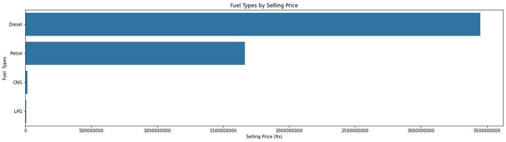

```python
#plotting the relationship between the fuel types and the selling price
plt.figure(figsize = [20, 5])
base_color=sns.color_palette()[0]
ax = plt.gca()
ax.ticklabel_format(useOffset=False, style='plain')
fuel_type = used_car.groupby('fuel').selling_price.sum().sort_values( ascending = False)
sns.barplot(fuel_type,fuel_type.index,color=base_color);
ax.set_title('Fuel Types by Selling Price')
ax.set_xlabel('Selling Price (Rs)')
ax.set_ylabel('Fuel  Types');
```

Also the Diesel is a predictor of price of the used car as it commands the highest selling price

## The relationship between Fuel and Sold Status

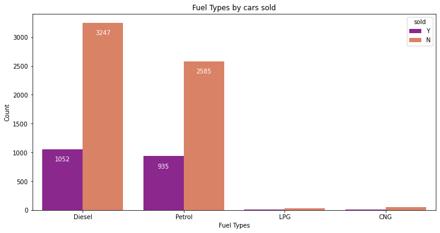

```python
# plotting a coutplot to determine which fuel type are sold more
plt.figure(figsize = [12,6])
ax = sns.countplot(data = used_car,x = 'fuel',hue ='sold',palette = 'plasma')
ax.set_title('Fuel Types by cars sold')
ax.set_xlabel('Fuel Types')
ax.set_ylabel('Count')
for p in ax.patches:
    ax.annotate(f'\n{p.get_height()}', (p.get_x()+0.2, p.get_height()), ha='center', va='top', color='white', size=10)
plt.show()
```

Observation It shown that the used cars both use Diesel and Petrol ,both are being accounted for being sold in the same range but the diesel is slightly higher

## The relationship of the owner types with the selling price

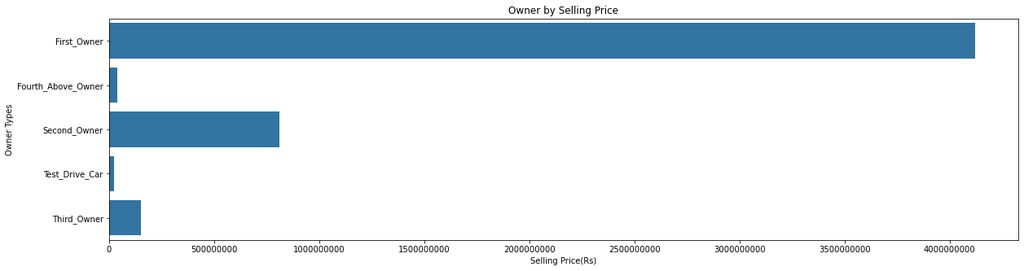

```python
#plotting the relationship betweenthe owner and selling price
plt.figure(figsize = [20, 5])
base_color=sns.color_palette()[0]
ax = plt.gca()
ax.ticklabel_format(useOffset=False, style='plain')
owner_type = used_car.groupby('owner').selling_price.sum()
sns.barplot(owner_type,owner_type.index,color=base_color)
ax.set_title('Owner by Selling Price')
ax.set_xlabel('Selling Price(Rs)')
ax.set_ylabel('Owner Types');
```

Observation

it indicates the the owner on the first_owner has a high significant relathionship between selling price of the car so its a good predictor of price. Most of the cars are sold are sold on first_owner basis

## The relationship between Owner and Sold Status

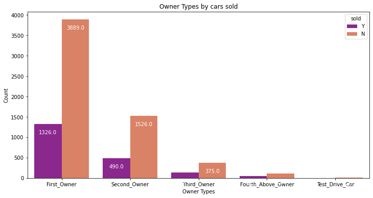

```python
#plotting a plot to show the relationship of being sold and unsold
plt.figure(figsize = [12,6])
ax = sns.countplot(data = used_car,x = 'owner',hue ='sold',palette ='plasma')
ax.set_title('Owner Types by cars sold')
ax.set_xlabel('Owner Types')
ax.set_ylabel('Count')
for p in ax.patches:
    ax.annotate(f'\n{p.get_height()}', (p.get_x()+0.2, p.get_height()), ha='center', va='top', color='white', size=10)
plt.show()
```

Observation Even though most of the used cars are being unsold from the proportion of the sold it can be seen that owner on first ownerbasis are sold more

## The relationship between Brand names and Price

```python
#calculate sum of selling Price for each Brand name of used car
name_by_selling_price =used_car.groupby('name').selling_price.sum().sort_values(ascending= False)
```

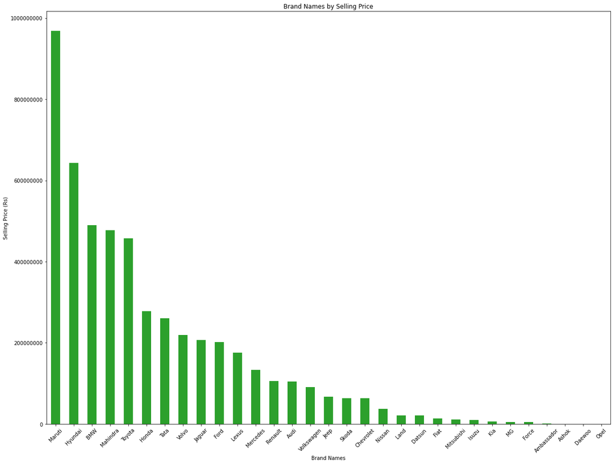

```python
#calculate sum of selling Price for each Brand name of used car
plt.figure(figsize=(20,15))
#create bar plot with custom aesthetics
base_color = sns.color_palette()[2]
ax = plt.gca()
ax.ticklabel_format(useOffset=False, style='plain', axis='y')
name_by_selling_price.plot(kind='bar', title='Brand Names by Selling Price',color = base_color,
               ylabel='Selling Price (Rs)', xlabel='Brand Names')

#rotate x-axis ticks vertically
plt.xticks(rotation=45);
```

Observation

It indicates that the name Mariuti,Hyundai,Bmw and Mahindra command a higher selling price and so its a good predictor of price

## The Relationship between Brand Names and Sold Status

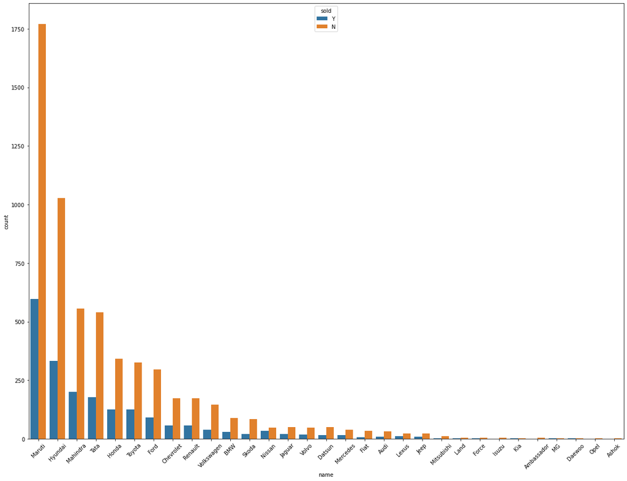

```python
#plotting to display the relationship showing which brand names sold
plt.figure(figsize = [20,15])
sns.countplot(data = used_car,x = 'name',hue ='sold',order =used_car['name'].value_counts().index)
#rotate x-axis ticks vertically
plt.xticks(rotation=45);
```

Obsevation It indicates that the used car name Mairuiti ,Hyundai,Mahindra and Tata are sold more

## The relationship between Region and Price

Analyzing the region to see if it is a good predict for used cars

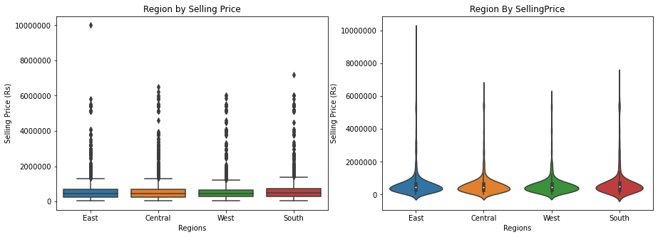

```python
#creating a plot to show the relationship of Region and selling price
plt.figure(figsize = [15,5])
plt.subplot(1,2,1)
ax = plt.gca()
ax.ticklabel_format(useOffset=False, style='plain')
sns.boxplot(data = used_car,x = 'Region',y = 'selling_price' );
ax.set_title('Region by Selling Price')
ax.set_xlabel('Regions')
ax.set_ylabel('Selling Price (Rs)')
plt.subplot(1,2,2)
ax = plt.gca()
ax.ticklabel_format(useOffset=False, style='plain')
sns.violinplot(data = used_car,x = 'Region',y = 'selling_price' );
ax.set_title('Region By SellingPrice')
ax.set_xlabel('Regions')
ax.set_ylabel('Selling Price (Rs)');
```

Observation

This describes how the Regions (East,Central,West,South) is significant in predicting the price of a used car It shows that the east region had the highest selling price for cars here we can see the presence of an outlier in the east region that increases the price to the highest level,the followed by the south region which also have an outlier

## The Relationship between Region and Sold Status

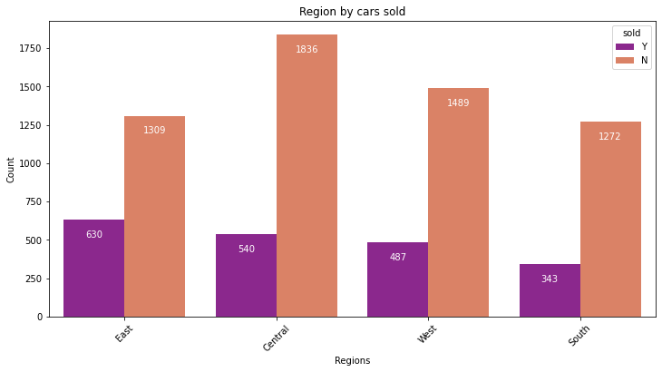

```python
# plot to find out which region had more more cars sold and unsold
plt.figure(figsize = [12,6])
ax =sns.countplot(data = used_car,x = 'Region',hue ='sold',palette ='plasma')
ax.set_title('Region by cars sold')
ax.set_xlabel('Regions')
ax.set_ylabel('Count')
#rotate x-axis ticks vertically
plt.xticks(rotation=45);
for p in ax.patches:
    ax.annotate(f'\n{p.get_height()}', (p.get_x()+0.2, p.get_height()), ha='center', va='top', color='white', size=10)
plt.show()
```

Obsevation

This indicates that the used cars are sold comparatively in the regions with just the east region having a slightly higher values

## The Relationship between Transmission and Sold Status

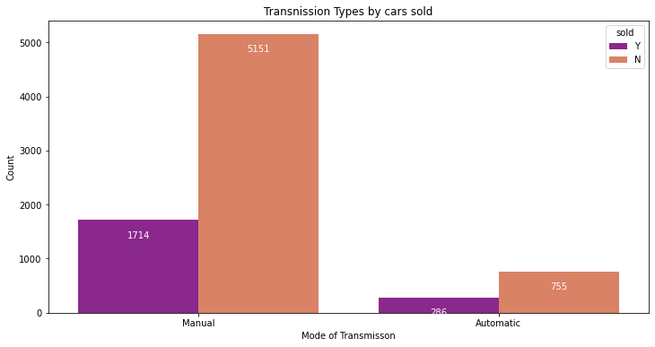

```python
## plot to sisplay the relationship between transmission mode and to know the count that got sold
plt.figure(figsize = [12,6])
ax =sns.countplot(data = used_car,x = 'transmission',hue ='sold',palette = 'plasma')
ax.set_title('Transnission Types by cars sold')
ax.set_xlabel('Mode of Transmisson')
ax.set_ylabel('Count')
for p in ax.patches:
    ax.annotate(f'\n{p.get_height()}', (p.get_x()+0.2, p.get_height()), ha='center', va='top', color='white', size=10)
plt.show()
```

Observation

For the transmission the Manual got more sold than Automatic and also it has a higher proportion of unsold than the Automatic

## The Relationship between Transmission and Price

```python
#calculate sum of selling Price for each transmission mode of used car
transmission_by_sold = used_car.groupby('transmission').selling_price.sum().sort_values(ascending = False)
```

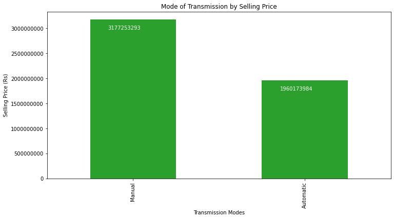

```python
#plotting a plot to show the mode of transmission and the selling  price
plt.figure(figsize=(12,6))
#create bar plot with custom aesthetics
base_color = sns.color_palette()[2]
ax = plt.gca()
ax.ticklabel_format(useOffset=False, style='plain', axis='y')
transmission_by_sold.plot(kind='bar', title='Mode of Transmission by Selling Price',color = base_color,
               ylabel='Selling Price (Rs)', xlabel='Transmission Modes');
for p in ax.patches:
    ax.annotate(f'\n{p.get_height()}', (p.get_x()+0.2, p.get_height()), ha='center', va='top', color='white', size=10)
plt.show()
```

Obsevation

It indicates that used car Transmission mode Manual are being sold more

## Relationship between other features that are not our main feature of interest such as seller types and seats

```python
used_car['seats'].unique()
```

```
array([ 5,  4,  7,  8,  6,  9, 10, 14,  2], dtype=int64)
```

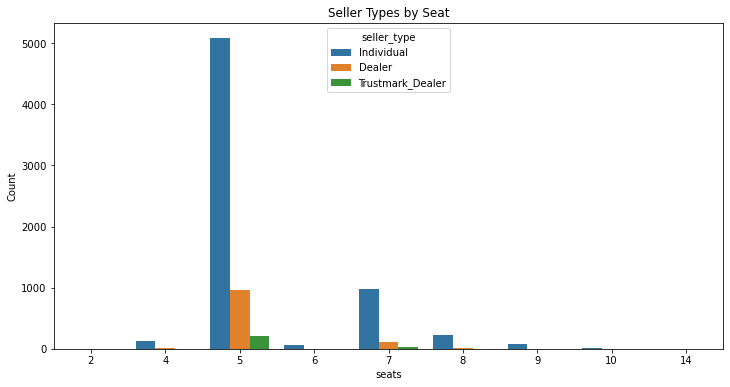

```python
#plot to show the relationship between seat and seller type
plt.figure(figsize =(12,6))
sns.countplot(data = used_car, x = 'seats', hue = 'seller_type')
plt.title('Seller Types by Seat')
plt.xlabel('seats')
plt.ylabel('Count');
```

Obsevation

The used car that has the seats that are 5 are more favoured by sellertypes on individual bases

## Insights Gained During Bivariate Exploration

1.Examining the relationship between mileage and selling price shows us that most of the milleage of the cares are around 10=30 and still commands a low selling price. Also in examining the relationship of those sold and unsold most of the used cars are still unsold

2.The relationship between engine size and selling price is of a weak postive correlation so enginne size doe not predicts price of the used car as most of the data points are scattered and very few having a significant relation to high price. For engine size increase in engine size doesnt seem to have any significant relation as it being sold or unsold.

3.Most of used cars are not being driven more so the proportion of the unsold used cars are more than the sold and the selling price doesnt increase

4.most of the used cars are Diesel types and they command a high selling price while Fuel type doesn't seem to have any significant relation as almost equal number of Petrol and Diesel cars are being sold.

5.Most of the used cars are on first owner basis and this commands a high selling price compare to the others. and most of first owner basis are sold more This could be a good determing factor for price.

6.The name Mariuti,Hyunda are being sold more and command the highest selling price so brand name could be a determing factor for price.

7.The east Region have a high asignificant relation to high price and also being sold and unsold.

8.The Transmission Mode the Manual has a high significant relation to selling price and sold than the automatic

# Multivariate Exploration

## Trends of FuelTypes By Year

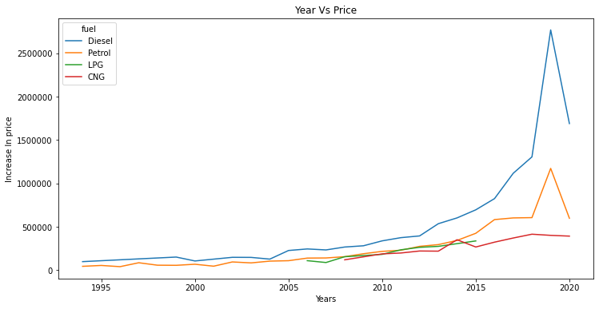

```python
# plot to show the relationship of the  between Priceand fueltypes by year
plt.figure(figsize=(12,6))
ax = plt.gca()
ax.ticklabel_format(useOffset=False, style='plain')
ax.set_xlabel('Years')
ax.set_ylabel('Increase In price')
ax.set_title("Year Vs Price")
sns.lineplot(data = used_car,x ='year',y ='selling_price',hue = 'fuel',ci = None);
```

## Trends showing what type of transmission had the highest price for fuel type

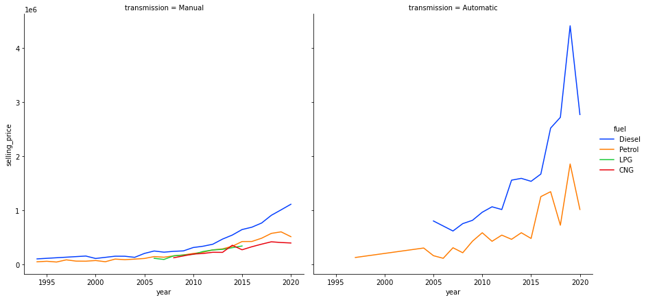

```python
# plotting a lineplot using transmission and fuel for  determining the facet of the grid

plt.figure(figsize=(12,8));
sns.relplot(data =used_car,x ='year',y ='selling_price',palette= 'bright',height =6,kind ='line',col = 'transmission',hue ='fuel',ci = None);
```

Obsevation

We can determine that when fuel type is diesel, it has the highest Price and for mode of transmission is the Automatic transmission also for Manual is the Diesel